# Exercise 3

# Task 1: Reflection

# Task 2: Lord of the Rings

## Load and clean data

First we load, restructure, and clean the data.

```r
# You'll only need the tidyverse library for this exercise
library(tidyverse)

# Load the separate datasets
fellowship <- read_csv("data/The_Fellowship_Of_The_Ring.csv")
tt <- read_csv("data/The_Two_Towers.csv")
rotk <- read_csv("data/The_Return_Of_The_King.csv")

# bind_rows() stacks data frames on top of each other
lotr_wide <- bind_rows(fellowship, tt, rotk) %>%
  # Make the Film column a categorical variable (factor), and put it in the
  # order the categories appear (so the films are in the correct order)
  mutate(Film = fct_inorder(Film))

# Make this wide data tidy
lotr <- lotr_wide %>%
  # This is the new way to make data long
  pivot_longer(cols = c(Female, Male),
               names_to = "Gender", values_to = "Words")
  # This is the old way that you learned in the RStudio primer on tidy data
  # gather(key = "Gender", value = "Words", Female, Male)
```

## Race

Does a certain race dominate the entire trilogy? (hint: group by `Race`)

```r
lotr_race <- lotr %>%
  group_by(Race) %>%
  summarise(word_count = sum(Words))
lotr_race
```

```
## # A tibble: 3 x 2
##   Race   word_count
##   <chr>       <dbl>
## 1 Elf          3737
## 2 Hobbit       8796
## 3 Man          8712
```

## Gender and film

Does a certain gender dominate a movie? (lolz of course it does, but still, graph it) (Hint: group by both `Gender` and `Film`.) Experiment with filling by `Gender` or `Film` and faceting by `Gender` or `Film`.

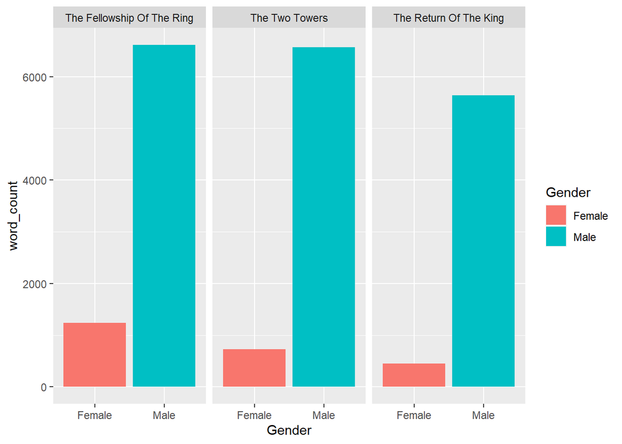

```r
lotr %>%
  group_by(Gender, Film) %>%
  summarise(word_count = sum(Words)) %>%
  ggplot(mapping = aes(x = Gender, y = word_count, fill = Gender)) +
   geom_col(position = "dodge") +
   facet_wrap(~ Film)
```

## Race and film

Does the dominant race differ across the three movies? (Hint: group by both `Race` and `Film`.) Experiment with filling by `Race` or `Film` and faceting by `Race` or `Film`.

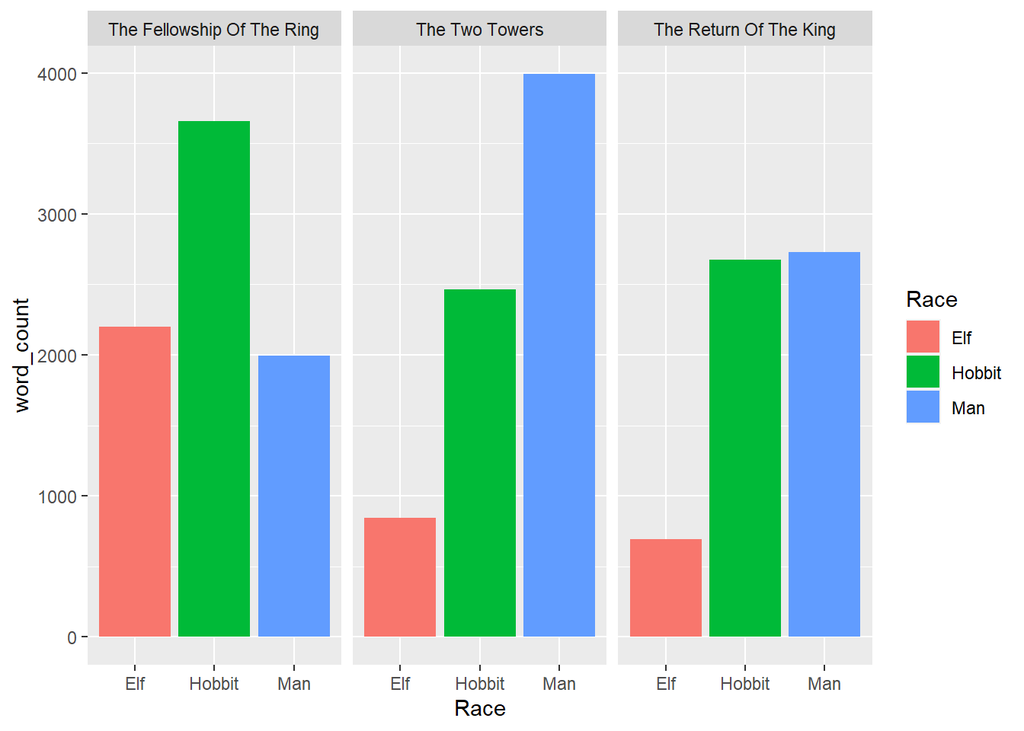

```r
lotr %>%
  group_by(Race, Film) %>%
  summarise(word_count = sum(Words)) %>%
  ggplot(mapping = aes(x = Race, y = word_count, fill = Race)) +
    geom_col(position = "dodge") +
    facet_wrap(~ Film)
```

## Race and gender and film

Create a plot that visualizes the number of words spoken by race, gender, and film simultaneously. Use the complete tidy `lotr` data frame. You don’t need to create a new summarized dataset (with `group_by(Race, Gender, Film)`) because the original data already has a row for each of those (you could make a summarized dataset, but it would be identical to the full version).

You need to show `Race`, `Gender`, and `Film` at the same time, but you only have two possible aesthetics (`x` and `fill`), so you’ll also need to facet by the third. Play around with different combinations (e.g. try `x = Race`, then `x = Film`) until you find one that tells the clearest story. For fun, add a `labs()` layer to add a title and subtitle and caption.

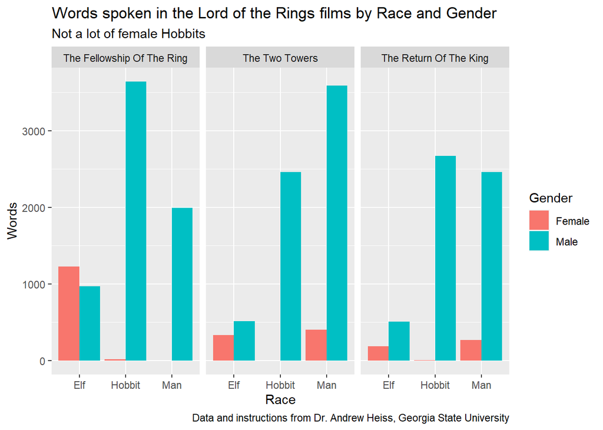

```r
lotr %>%
  ggplot(mapping = aes(x = Race, y = Words, fill = Gender)) +
    geom_col(position = "dodge") +
    facet_wrap(~ Film) +
    labs(title = "Words spoken in the Lord of the Rings films by Race and Gender",
         subtitle = "Not a lot of female Hobbits",
         caption = "Data and instructions from Dr. Andrew Heiss, Georgia State University") +
    theme_gray()
```